# PEPA Día 1 - Clase 2

Arturo De Zan | Sergio Garcia Mora

11/6/2021

# Estadística para gente analítica

Recuerden que para utilizar el código de este documento html pueden copiar y pegar el código, o crear directamente un script descargando el archivo en la carpeta del proyecto, y en la consola de R escribir:

```r
knitr::purl("pepa_2.Rmd")
```

En esta clase vamos a trabajar con los siguientes paquetes:

```r
library(readxl)       # Carga de archivos de Excel
library(tidyverse)    # Carga, limpieza, transformación y visualización de datos
library(funModeling)  # Análisis Exploratorio de Datos
library(lubridate)    # Trabajar con fechas
```

Nuevamente, utilizaremos las mismas fuentes de datos que en el módulo anterior:

```r
plantel <- read_excel("datos/plantel.xlsx")
kiwi <- read_csv("datos/kiwi_rh.csv") %>% filter(pais == "Argentina")
```

```r
plantel <- plantel %>%
  mutate(anio_ingreso = floor_date(fecha_ingreso,
                                   unit = "year"),  # Extrae el año de la fecha ingreso
         q_ingreso = quarter(fecha_ingreso))  # Columna nueva con el trimestre


# Creamos una nueva columna uniendo las nuevas columnas que acabamos de crear
plantel$anioq_ingreso <- paste(plantel$anio_ingreso, plantel$q_ingreso, sep = "-")


# Creamos una columna con las generaciones a la que pertenecen los empleados
# Fuente: https://www.mckinsey.com/industries/consumer-packaged-goods/our-insights/true-gen-generation-z-and-its-implications-for-companies#
plantel <- plantel %>%
  mutate(anio_nacimiento = year(fecha_nacimiento),
         generacion = case_when(
           anio_nacimiento <= 1959 ~ "Baby Boomer",
           anio_nacimiento <= 1979 ~ "Gen X",
           anio_nacimiento <= 1994 ~ "Gen Y",
           anio_nacimiento = TRUE  ~ "Gen Z"
  )) %>%
  select(-anio_nacimiento) # Elimina la columna anio_nacimiento


# Limpieza sueldos Encuesta KIWI
# Creamos un objeto con los resultados de la función
limpieza <- profiling_num(kiwi$sueldo_bruto)

# Creo objetos almacenando los valores de los percentiles 5 y 95
p05 <- limpieza[1,6]
p95 <- limpieza[1,10]

# Creo un nuevo data frame llamado 'sueldos'
sueldos <- kiwi %>%
  filter(tipo_contratacion != "Part time",  # Filtro los que no sean Part time
         between(sueldo_bruto,              # Variable a filtrar con 'between'
                 p05,                       # Filtro inferior
                 p95))                      # Filtro superior
```

## Población y muestra

Por ejemplo, los datos del data frame `plantel` corresponden a un listado de empleados de una empresa. La **población** de empleados es 7383. Una **muestra**de los empleados podría ser:

- *Las personas en el Nivel de Contribución Operativo*
- *El conjunto de mujeres en posiciones de liderazgo*
- *Las personas de la Generación X*

```r
# Ejemplo 1
plantel %>%
  filter(nivel_contribucion == "Operativo") %>%
  count()
```

```
## # A tibble: 1 x 1
##       n
##   <int>
## 1  5398
```

```r
# Ejemplo 2
plantel %>%
  filter(nivel_contribucion %in% c("Líder Equipo", "Gerencia", "Dirección"),
         sexo == "Femenino") %>%
  count(nivel_contribucion)
```

```
## # A tibble: 3 x 2
##   nivel_contribucion     n
##   <chr>              <int>
## 1 Dirección              5
## 2 Gerencia              18
## 3 Líder Equipo         115
```

```r
# Ejemplo 3
plantel %>%
  filter(generacion == "Gen X") %>%
  count()
```

```
## # A tibble: 1 x 1
##       n
##   <int>
## 1  3165
```

# Medidas de Posición

## Promedio

[figure not shown]

El **promedio** o **media muestral** es una medida de tendencia central 🤯 con el que todas y todos estamos bastante familiarizadas y familiarizados. Es una métrica muy útil porque todo el que cursó una materia en el colegio sabe como se calcula, y qué significa su resultado.

> El promedio es el valor más representativo de un conjunto de datos… (ponele)…

La función en R para calcular el promedio se llama `mean()`. Por ejemplo, calculemos la edad promedio de nuestro `plantel`.

```r
promedio <- mean(plantel$edad)

promedio
```

```
## [1] 39.51294
```

El promedio de edad en esta empresa es 39.5129351. Una forma de representarlo visualmente es de la siguiente manera:

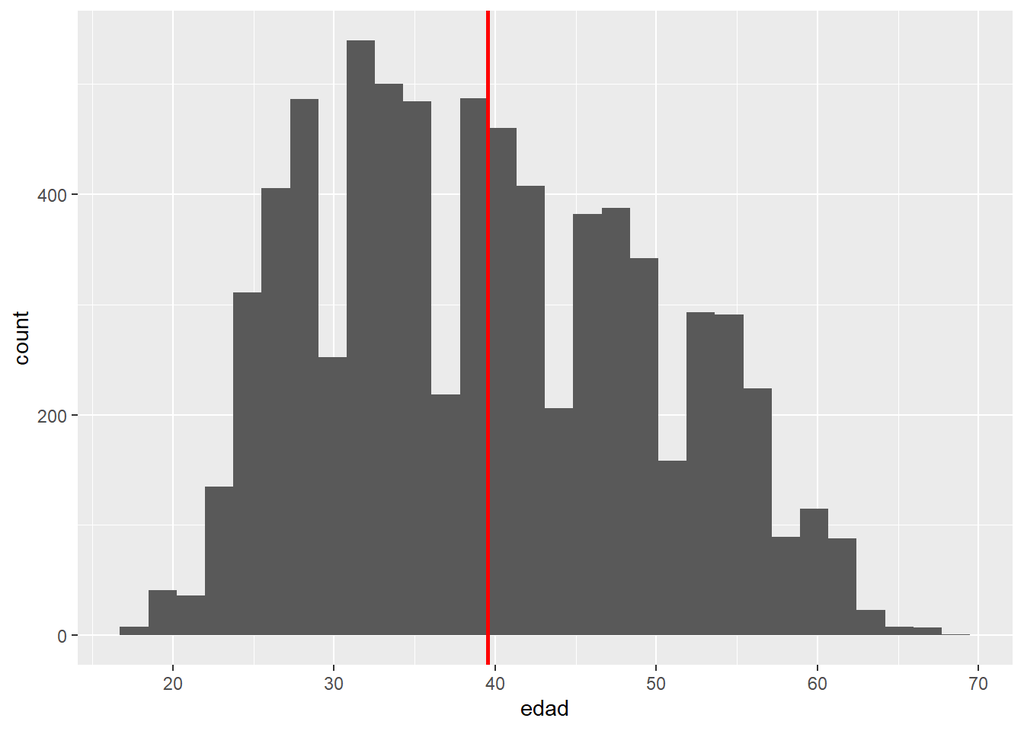

```r
ggplot(plantel, aes(x = edad)) +
  geom_histogram() +
  geom_vline(xintercept = promedio, size = 1, color = "red")
```

Una propiedad que tiene el promedio es que la suma de las distancias de cada uno de los puntos al promedio es la más chica posible (o sea que si resto el valor de cada edad al promedio, para todos los casos, el resultado total es el más chico posible).

Veamos esto con un dataset más chico:

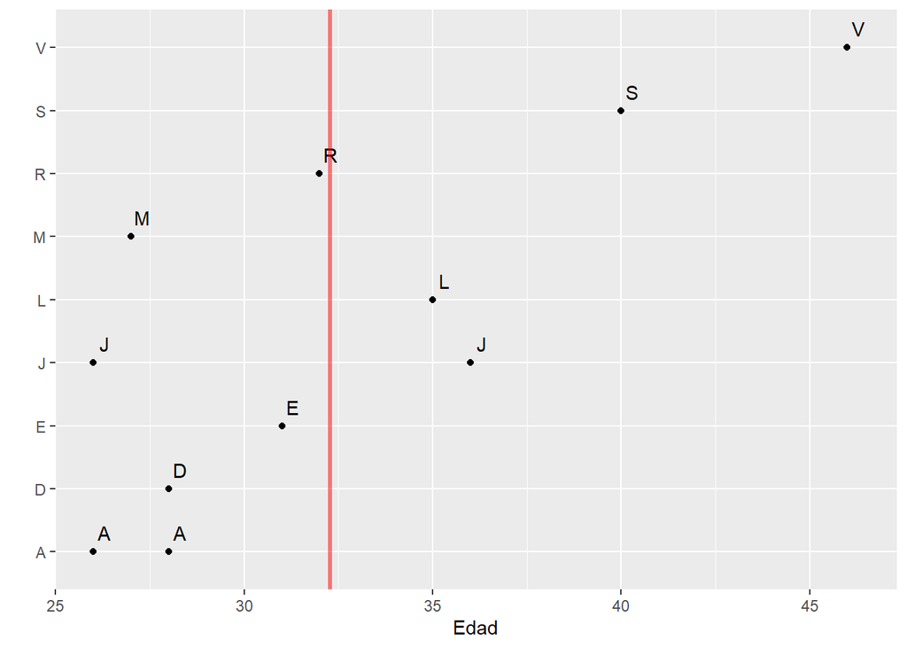

```r
# Cargamos el archivo
edades <- read_excel("datos/edades.xlsx")

# Graficamos la edad de cada participante
ggplot(edades, aes(x = Edad, y = Inicial, label = Inicial))+
  geom_point() +
  labs(y="")+
  geom_text(nudge_x = 0.3, nudge_y = 0.3) +
  geom_vline(xintercept = mean(edades$Edad), color = "red", size = 1.2, alpha = 0.5)
```

## Mediana

> *Cada cosa en su lugar y un lugar para cada cosa*

[figure not shown]

Así como el promedio es una medida de *tendencia central*, al igual que la **mediana.** Los **cuartiles** son medidas **de orden** (por ende los *cuantiles o percentiles* también lo son). Lo que hacen estas medidas es ordenar los datos de mayor a menor, y nos indican cuál es el valor que está en:

- El valor correspondiente al 25% de los datos: **Primer cuartil**
- El valor correspondiente al 50% de los datos: La **mediana** (el **segundo cuartil**)
- El valor correspondiente al 75% de los datos: **Tercer cuartil.**

Calculemos la mediana de `sueldo_bruto` de la Encuesta KIWI

```r
mediana <- median(kiwi$sueldo_bruto)

mediana
```

```
## [1] 72000
```

También podemos calcular manualmente los valores de los percentiles con la función `quantile()`. Por ejemplo, calculemos el percentil 20.

```r
quantile(kiwi$sueldo_bruto, 0.2)
```

```
##     20%
## 48998.4
```

Si queremos ver los valores de los **quintiles** (los valores que dividen al dataset en 5 partes), la forma de hacerlo es la siguiente:

```r
quantile(kiwi$sueldo_bruto, c(0.2, 0.4, 0.6, 0.8))
```

```
##      20%      40%      60%      80%
##  48998.4  64698.2  80000.0 115000.0
```

Ya exploraremos otras propiedades y características del promedio y la mediana. Ahora vamos a ver otra medida, la **moda** 💅.

## Moda

La **moda** es una medida que muestra el valor que mayor cantidad de veces se repite. Por ejemplo, en nuestro archivo de `plantel` podemos buscar cuál es el valor de edad que más se repite.

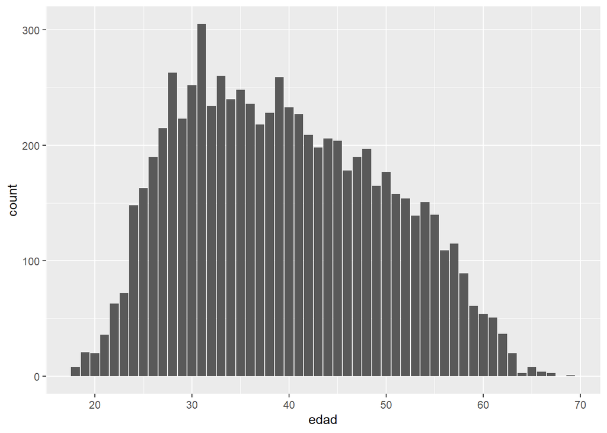

```r
ggplot(plantel, aes(x = edad)) +
  geom_bar()
```

```r
plantel %>%
  count(edad, sort = T) %>%
  head()
```

```
## # A tibble: 6 x 2
##    edad     n
##   <dbl> <int>
## 1    31   305
## 2    28   263
## 3    33   260
## 4    39   259
## 5    30   252
## 6    35   248
```

Como podemos apreciar en las salidas anteriores vemos que el número 31 es el que **más veces se repite**, por eso no hay que confundir *moda* con *promedio*. El único caso en que pueden tener el mismo valor es cuando la distribución de los datos es normal.

La moda también la podemos calcular sobre *variables categóricas*. Usando la Encuesta KIWI fijémonos cuál es el ERP más utilizado en RH.

```r
kiwi %>%
  filter(erp != "No tenemos sistema de gestión") %>%
  count(erp, sort = T) %>%
  head()
```

```
## # A tibble: 6 x 2
##   erp                      n
##   <chr>                <int>
## 1 SAP / SuccessFactors    70
## 2 Enlatado propio         58
## 3 Tango                   57
## 4 RH Pro                  40
## 5 Bejerman                37
## 6 Meta4                   24
```

Así que podemos apreciar que el valor que más se repite es el de *SAP / SuccessFactors*.

## Características y particularidades de estas tres medidas

### Sensibilidad a valores extremos

Como sabemos, el promedio (o media), a diferencia de lo que sucede con la mediana y la moda, es sensible a los valores extremos. Por ejemplo, miremos los valores de resumen de los sueldos de la Encuesta KIWI:

```r
summary(kiwi$sueldo_bruto)
```

```
##    Min. 1st Qu.  Median    Mean 3rd Qu.    Max.
##       0   52000   72000   90638  102000 2140000
```

La función `summary()` nos permite ver rápidamente:

- Los valores **mínimo** y **máximo**.
- El **primer** y **tercer cuartil**.
- La **mediana** (median).
- El **promedio** (mean).

En la salida anterior podemos ver que tenemos un sueldo muy alto, ($ 2.140.000) que como vimos en el módulo anterior, es un valor muuuuy atípico. Presten atención al promedio (90.638), y la mediana (72.000).

Comparemos los resultados cuando *podamos* los valores por encima y por debajo de los percentiles 5 y 95.

```r
summary(sueldos$sueldo_bruto)
```

```
##    Min. 1st Qu.  Median    Mean 3rd Qu.    Max.
##   29400   55000   73000   82422  100000  210000
```

Ahora, con los valores “podados” podemos ver que el promedio ahora es de $ 82.422 (una diferencia cercana al 10%). Mientras que la diferencia entre las medianas la diferencia es sólo de 1%.

### Suma y multiplicación de constantes

Si la misma constante se suma a cada valor del data set, el promedio va a incrementarse por el mismo valor de la constante.

Por ejemplo, tomemos las edades del dataset `edades`.

```r
edades <- edades$Edad

# Estos son los valores
edades
```

```
##  [1] 35 28 36 32 28 26 46 31 27 26 40
```

Calculemos el promedio de edad:

```r
# Si ponemos todo el código entre paréntisis R crea el objeto y muestra el resultado
(promedio <- mean(edades))
```

```
## [1] 32.27273
```

Ahora sumemos al vector `edades` un número al azar, por ejemplo, 15.

```r
edades_2 <- edades + 15

edades_2
```

```
##  [1] 50 43 51 47 43 41 61 46 42 41 55
```

¿Qué pasará con el promedio? Veamos.

```r
mean(edades_2)
```

```
## [1] 47.27273
```

Vemos que el nuevo promedio es justamente igual al promedio original más la constante.

# Medidas de forma

Tomemos la Encuesta KIWI y usemos la columna `anios_en_puesto` que nos dice la cantidad de años de experiencia en el puesto.

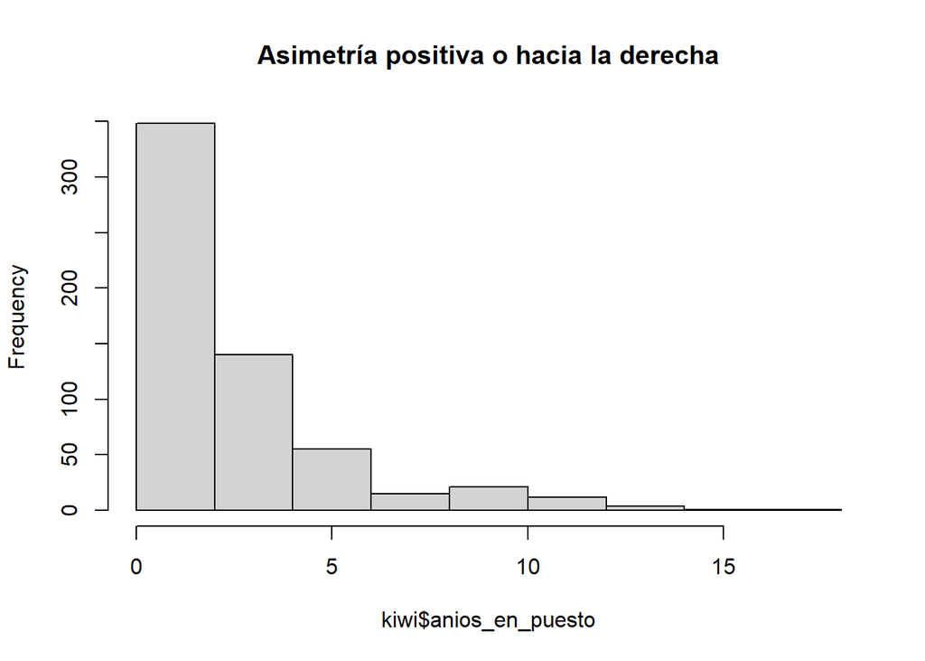

```r
hist(kiwi$anios_en_puesto, main = "Asimetría positiva o hacia la derecha")
```

Veamos qué valores nos arroja la función `summary`

```r
summary(kiwi$anios_en_puesto)
```

```
##    Min. 1st Qu.  Median    Mean 3rd Qu.    Max.
##   0.000   1.000   2.000   2.832   4.000  17.000
```

Y veamos cual es el valor más frecuente:

```r
kiwi %>%
  count(anios_en_puesto, sort = T) %>%
  head(1)
```

```
## # A tibble: 1 x 2
##   anios_en_puesto     n
##             <dbl> <int>
## 1               2   128
```

En este caso podemos ver que la respuesta más frecuente es 2 años de experiencia.

Otra variable interesante de la Encuesta KIWI es el nivel de satisfacción con la empresa. Hagamos un gráfico de barras

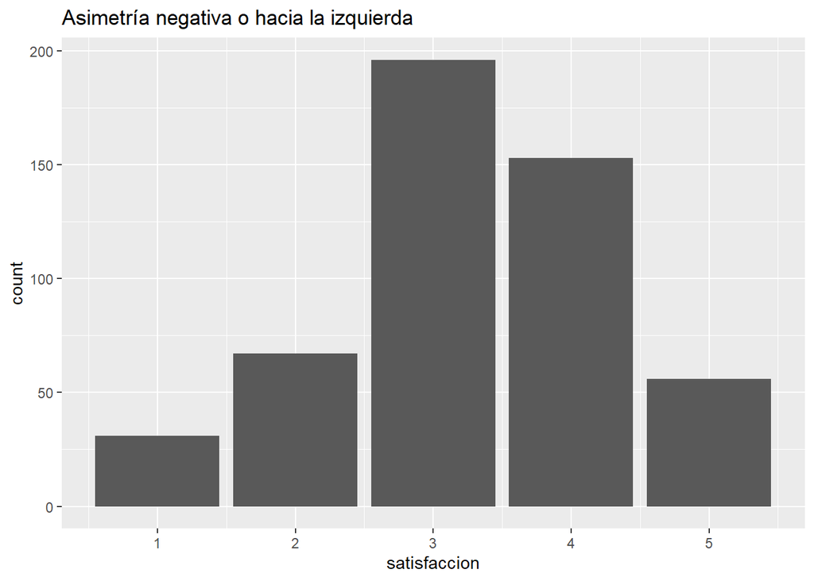

```r
satisf <- kiwi %>%
  filter(!is.na(satisfaccion)) %>%
  select(satisfaccion)

ggplot(satisf, aes(x = satisfaccion)) +
  geom_bar() +
  ggtitle("Asimetría negativa o hacia la izquierda")
```

Eduardo Bologna nos aporta la siguiente definición: *La asimetría puede evaluarse directamente a partir de las medidas de centralidad, ya que la posición relativa de la media y la mediana indican hacia dónde ésta sucede. Cuando la **media y la mediana coinciden**, la distribución es simétrica, es decir carece de asimetría. Si la **media supera a la mediana**, se trata de una distribución asimétrica a la derecha y si la **media es menor que la mediana**, la asimetría será hacia la izquierda*[^1]. Pasando en limpio:

- Cuando la media (promedio) es igual a la mediana: la distribución es simétrica.
- Cuando la media es mayor que la mediana, la asimetría es positiva o hacia la derecha.
- Cuando la media es menor que la mediana, la asimetría es negativa o hacia la izquierda.
[^1]: Bologna, E. Un recorrido por los métodos cuantitativos en Ciencias Sociales a bordo de R. https://estadisticacienciassocialesr.rbind.io/la-expresi%C3%B3n-resumida-de-la-informaci%C3%B3n.html#la-forma-de-la-distribuci%C3%B3n